# HW1

Kelsey Grinde

1/29/2015

# Homework instructions:

Use the ggplot2 package to plot the Iris data showing length vs width facetting petal/sepal vs flower type, basically reproducing slide 27 of the lecture notes. Feel free to customize the styling as you see fit (color, font size, etc). (Source: raphg/Biostat-578/HW1.md)

# Load data and packages

First we need to load the data and other necessary packages:

```r
# load dataset
data(iris)
# load ggplot2 package for graphics
library(ggplot2)
# load reshape2 package for data reshaping
library(reshape2)
```

# Look at the data

Next we will look to see how the data is currently stored. Note that each row gives the sepal length and width, petal length and width, and species for one iris flower.

```r
head(iris)
```

```
##   Sepal.Length Sepal.Width Petal.Length Petal.Width Species
## 1          5.1         3.5          1.4         0.2  setosa
## 2          4.9         3.0          1.4         0.2  setosa
## 3          4.7         3.2          1.3         0.2  setosa
## 4          4.6         3.1          1.5         0.2  setosa
## 5          5.0         3.6          1.4         0.2  setosa
## 6          5.4         3.9          1.7         0.4  setosa
```

# Using `resphape2` to change how the data is stored in our data frame

We would like to have the data to be stored using two rows per flower instead of just one. In each row we would like the species and some sort of flower identification number, as well as the length and width for one of the parts of the flower (either the sepal or the petal). The second row for that flower will include the flower ID, species, and length and width for the other part of the flower that is not measured in the first row. To do this, we need to create ID numbers for the flowers and then reshape our data so that we have three columns “Length”, “Width”, and “Flower.Part” instead of the four “Sepal.Length”, “Sepal.Width”, “Petal.Length”, and “Petal.Width”.

```r
# add a column with ID for each flower
iris <- within(iris, ID <- 1:nrow(iris))

# look at the new column
head(iris)
```

```
##   Sepal.Length Sepal.Width Petal.Length Petal.Width Species ID
## 1          5.1         3.5          1.4         0.2  setosa  1
## 2          4.9         3.0          1.4         0.2  setosa  2
## 3          4.7         3.2          1.3         0.2  setosa  3
## 4          4.6         3.1          1.5         0.2  setosa  4
## 5          5.0         3.6          1.4         0.2  setosa  5
## 6          5.4         3.9          1.7         0.4  setosa  6
```

```r
# melt data frame so we have four rows per flower with sepal length, width, petal length, width
melted_iris <- melt(iris,id.vars=c('ID','Species'),variable.name = 'Measurement.Type')

# now it looks like:
head(melted_iris)
```

```
##   ID Species Measurement.Type value
## 1  1  setosa     Sepal.Length   5.1
## 2  2  setosa     Sepal.Length   4.9
## 3  3  setosa     Sepal.Length   4.7
## 4  4  setosa     Sepal.Length   4.6
## 5  5  setosa     Sepal.Length   5.0
## 6  6  setosa     Sepal.Length   5.4
```

```r
# change measurement type from factor to character
melted_iris <- within(melted_iris, {
  Measurement.Type <- as.character(Measurement.Type)
})

# create new columns that will say which part of the flower and which dimension is being measured. To do this we need to split the character "Sepal.Length", for example, at the middle "." which will return two parts: "Sepal" and "Length". We'll repeat this splitting process for each flower ID number and then store the flower parts ("Sepal","Petal") in a new column called "Flower.Part" and the dimension of measurement ("Width","Length") in a new column called "Dimension".
num_flowers <- nrow(melted_iris)
melted_iris <- within(melted_iris, {
  # strsplit(Measurement.Type,split='[.]') will create a list of length nrow(melted_iris)
  # where each item in the list contains two elements: flower part and dimension
  # we'll store the flower parts in Flower.Part and dimensions in Dimension
  Flower.Part <- unlist(strsplit(Measurement.Type,split='[.]'))[seq(1,num_flowers*2,2)]
  Dimension <- unlist(strsplit(Measurement.Type,split='[.]'))[seq(2,num_flowers*2,2)]
})

# remove the now unnecessary Measurement.Type column
melted_iris <- melted_iris[,-which(names(melted_iris)=='Measurement.Type')]

# look at what we have now
head(melted_iris)
```

```
##   ID Species value Dimension Flower.Part
## 1  1  setosa   5.1    Length       Sepal
## 2  2  setosa   4.9    Length       Sepal
## 3  3  setosa   4.7    Length       Sepal
## 4  4  setosa   4.6    Length       Sepal
## 5  5  setosa   5.0    Length       Sepal
## 6  6  setosa   5.4    Length       Sepal
```

```r
# now we'll cast so we have two rows per flower instead of 4
# we'll have five columns: ID, Species, Flower.Part, Length, and Width
cast_iris <- dcast(melted_iris,ID+Species+Flower.Part ~ Dimension)

# confirm that our data now looks like what we want: it does!
head(cast_iris)
```

```
##   ID Species Flower.Part Length Width
## 1  1  setosa       Petal    1.4   0.2
## 2  1  setosa       Sepal    5.1   3.5
## 3  2  setosa       Petal    1.4   0.2
## 4  2  setosa       Sepal    4.9   3.0
## 5  3  setosa       Petal    1.3   0.2
## 6  3  setosa       Sepal    4.7   3.2
```

# Use ggplot2 to further explore this dataset

Now that we reshaped our dataset, it will be easier to use the package `ggplot2`’s `facet_grid()` function to create a scatterplot of length measurements versus width measurements for these flowers, with a panel for each of the six species-flower part combinations (setosa petal, setosa sepal, versicolor petal, versicolor sepal, virginica petal, and virginica sepal).

Here is my replication of Slide 27 from the BIOST 578A lecture *Advanced Graphics in R*:

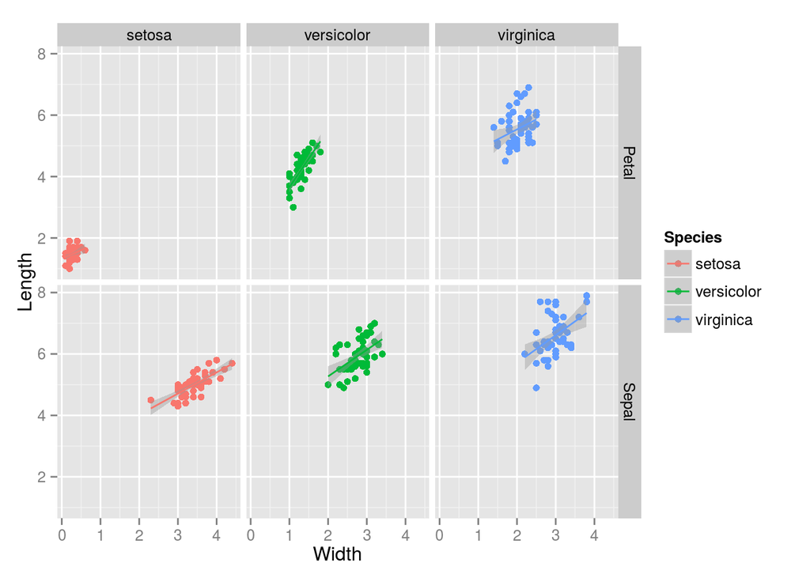

Here is a slightly different version that I also like:

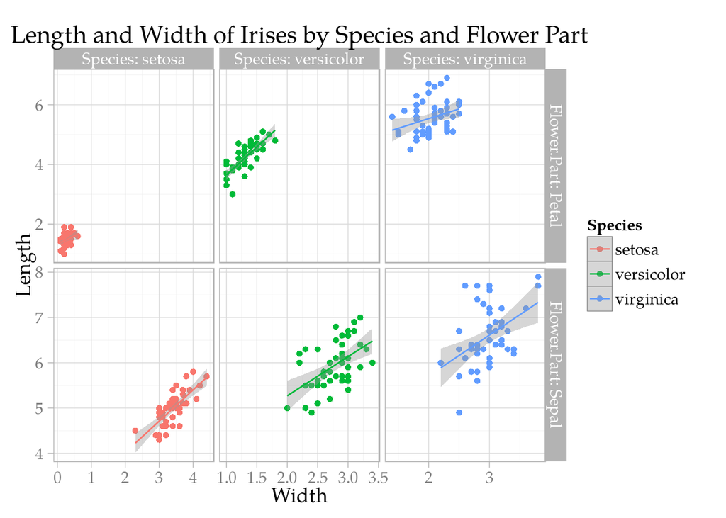

# The `R` code used to produce the plots above is here:

```r
# Plot 1: Reproduce Slide 27
ggplot(data=cast_iris)+
  geom_point(aes(x=Width,y=Length,color=Species))+
  geom_smooth(aes(x=Width,y=Length,group=Species,color=Species), method="lm")+
  facet_grid(Flower.Part~Species)

# Plot 2: Modify Slide 27
ggplot(data=cast_iris)+
  geom_point(aes(x=Width,y=Length,color=Species))+
  geom_smooth(aes(x=Width,y=Length,group=Species,color=Species), method="lm")+
  facet_grid(Flower.Part~Species,labeller=label_both,scales='free')+
  ggtitle('Length and Width of Irises by Species and Flower Part')+
  theme_light(base_size=14,base_family='Palatino')
```